# Reproducible research - Week 2 Project

##Inputing missing values

Q1 - TO find the rows with NAs, the function “Complete cases” give an immediate output.

```r
Number_NA_Rows <- sum(!complete.cases(data))
```

Q2/Q3 - In order to replace the missing values, the data set “data_mean_interval” created previously is used to replace the missing values with the mean of steps taken for respective time interval. Function “rows_patch” allows to replace the values with NA´s directly by matching the “interval” column value.

```r
data_Replaced_NAs <- data
data_Replaced_NAs <- rows_patch(data_Replaced_NAs, data_mean_interval, by = "interval")
```

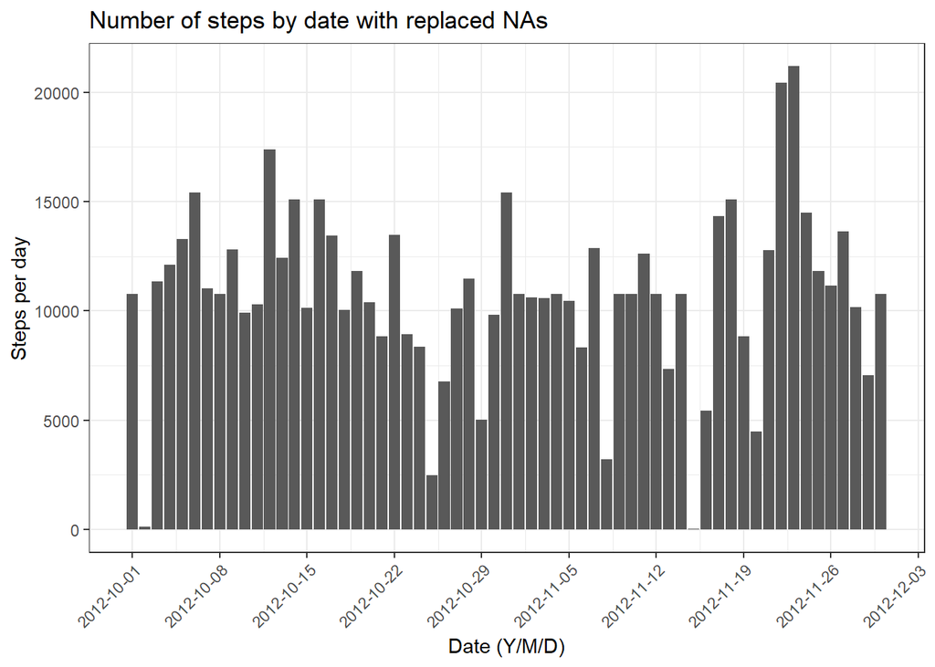

```r
data_replace_NA_sum_date <- data_Replaced_NAs  %>% group_by(date) %>% summarise_all(sum)
plot <- ggplot(data = data_replace_NA_sum_date, aes(x = date, y = steps)) + geom_histogram(stat = "identity", width=.9, position=position_dodge(.7))
plot + ggtitle("Number of steps by date with replaced NAs") + xlab("Date (Y/M/D)") + ylab("Steps per day") + scale_x_date(breaks = "week", labels = date_format("%Y-%m-%d")) + theme_bw()+ theme(axis.text.x = element_text(angle = 45, hjust = 1))
```

```r
data_replaceNA_mean <- mean(data_replace_NA_sum_date$steps)
data_replaceNA_median <- median(data_replace_NA_sum_date$steps)
data_replace_stats <- data.frame(data_replaceNA_mean, data_replaceNA_median)
```

The number of steps per day, without NA values had a mean of 10766.19 and a median of 10766.19.Comparing to the previous mean of 10766.19 and median of 10765, the impact of substituting the NAs with the average of the steps for each interval does not change significantly the outcome of mean and median.’

##Are there differences in activity patterns between weekdays and weekends?

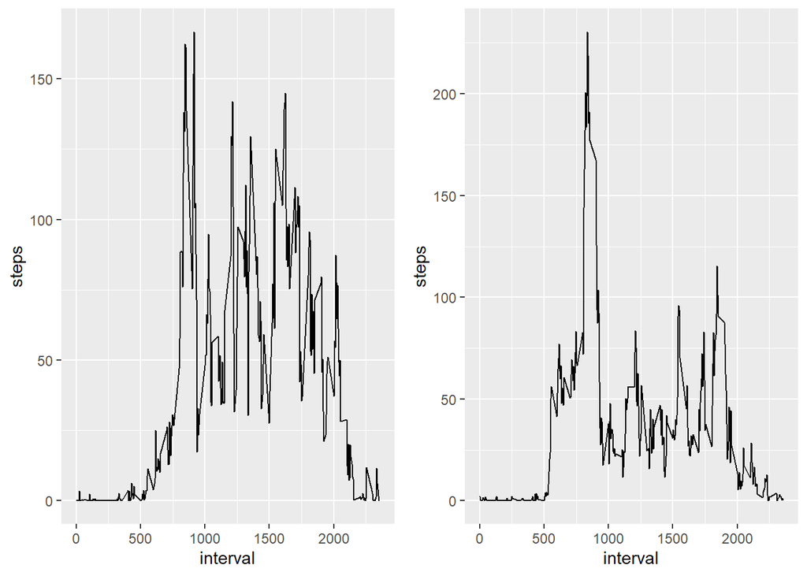

```r
data_Replaced_NAs$date <- as.Date(data_Replaced_NAs$date)
weekdays1 <- c('Monday', 'Tuesday', 'Wednesday', 'Thursday', 'Friday')
data_Replaced_NAs$wDay <- factor((weekdays(data_Replaced_NAs$date) %in% weekdays1), levels=c(FALSE, TRUE), labels=c('weekend', 'weekday'))

data_split <- data_Replaced_NAs %>% group_split(wDay)
data_mean_interval_week <- data_split[[1]] %>% subset(select=c(steps,interval)) %>% group_by(interval) %>% summarise_all(mean, na.rm = TRUE)
data_mean_interval_weekend <- data_split[[2]] %>% subset(select=c(steps,interval)) %>% group_by(interval) %>% summarise_all(mean, na.rm = TRUE)

p <- ggplot(data_mean_interval_week, aes(x=interval, y=steps)) + geom_line()
q <- ggplot(data_mean_interval_weekend, aes(x=interval, y=steps)) + geom_line()
grid.arrange(p, q, ncol = 2)
```